# Practical Machine Learning Coursera Project

Username:ldfernan

December 24, 2015

Six young health participants were asked to perform one set of 10 repetitions of the Unilateral Dumbbell Biceps Curl in five different fashions: exactly according to the specification (Class A), throwing the elbows to the front (Class B), lifting the dumbbell only halfway (Class C), lowering the dumbbell only halfway (Class D) and throwing the hips to the front (Class E).

Class A corresponds to the specified execution of the exercise, while the other 4 classes correspond to common mistakes. Participants were supervised by an experienced weight lifter to make sure the execution complied to the manner they were supposed to simulate. The goal of the machine learning exercise is to accurately predict the classe variable using the various on-body motion sensing readings available.

## Reading Data

We read data from csv files and also create functions to calculate error rates (misclassification rate) and create submission files

```r
require(dplyr);require(caret)
set.seed(345)

#Function:create submission files
pml_write_files = function(x){
  n = length(x)
  for(i in 1:n){
    filename = paste0("problem_id_",i,".txt")
    write.table(x[i],file=filename,quote=FALSE,row.names=FALSE,col.names=FALSE)
  }
}
#Function calculate error rate
err_rate = function(actual, pred) {
    err<-sum(pred != actual)/length(actual)
    paste("Error Rate is:",err,sep=" ")
}
#Read data from csv
train<-read.csv("./data/pml-training.csv")
test<-read.csv("./data/pml-testing.csv")
```

## Investigate and plot data

The train dataset has the “classe” variable and it is not present in test data. Also, the test dataset has the problem_id variable, which is not present in train. Scatterplot of existing variables, colored by classe variables did not show any interesting insights.

```r
dim(train)
```

```
## [1] 19622   160
```

```r
dim(test)
```

```
## [1]  20 160
```

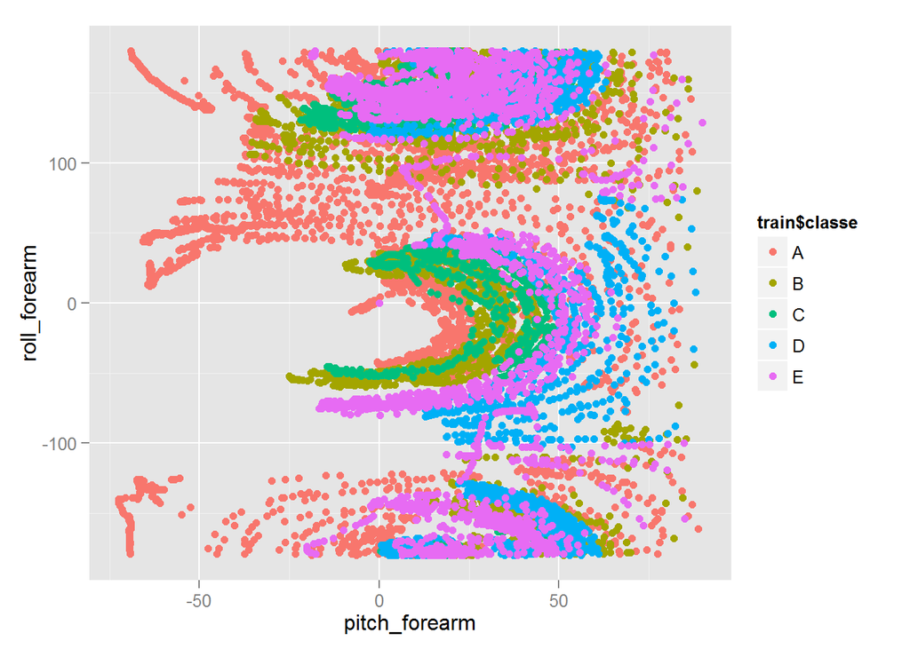

```r
#Arbitrary scatterplots did not show any linear classifications possible.
qplot(pitch_forearm,roll_forearm,data=train,col=train$classe)
```

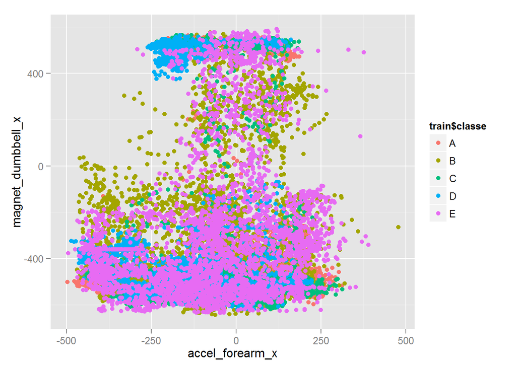

```r
qplot(accel_forearm_x,magnet_dumbbell_x,data=train,col=train$classe)
```

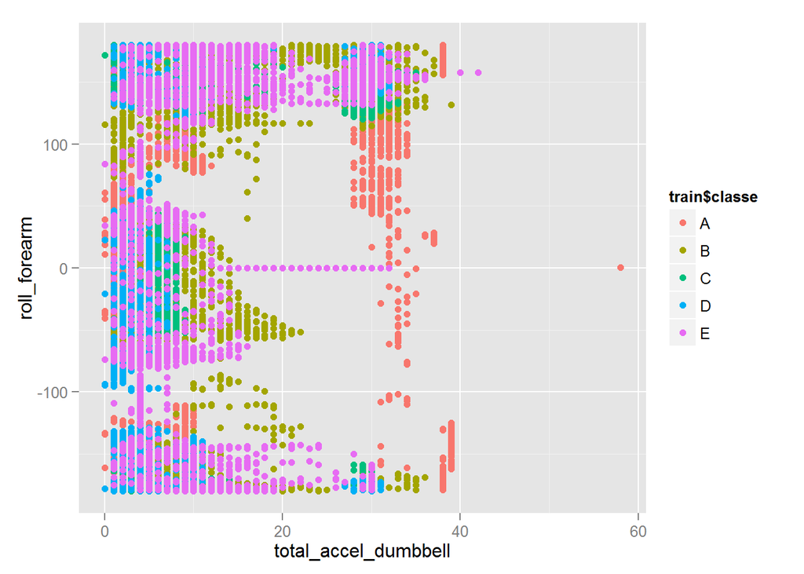

```r
qplot(total_accel_dumbbell,roll_forearm,data=train,col=train$classe)
```